# Predicting Stroke from Health Data

Balázs Margitai

2026-09-17

In this project I use the Kaggle stroke dataset to predict which patients had a stroke. Only about 5% of the patients in the data had one, and a lot of the work is about that imbalance: a model can be 95% accurate and still miss every single stroke patient.

I start with a logistic regression, fix the threshold problem, add a feature suggested by the exploratory analysis, and then compare the result with LDA and a random forest. Besides the usual classification metrics I also look at how well calibrated the predicted probabilities are, and I compare the models with repeated cross-validation instead of a single test split. A short summary is at the end of the report.

# 1. Data

The data comes from the [Stroke Prediction Dataset](https://www.kaggle.com/datasets/fedesoriano/stroke-prediction-dataset) on Kaggle.

```r
stroke_data = read.csv("data/healthcare-dataset-stroke-data.csv")

cat("Rows:", nrow(stroke_data), " Columns:", ncol(stroke_data), "\n\n")
```

```
## Rows: 5110  Columns: 12
```

```r
data.frame(column = names(stroke_data),
           type = sapply(stroke_data, function(x) class(x)[1]),
           distinct_values = sapply(stroke_data, function(x) length(unique(x))),
           row.names = NULL)
```

```
##               column      type distinct_values
## 1                 id   integer            5110
## 2             gender character               3
## 3                age   numeric             104
## 4       hypertension   integer               2
## 5      heart_disease   integer               2
## 6       ever_married character               2
## 7          work_type character               5
## 8     Residence_type character               2
## 9  avg_glucose_level   numeric            3979
## 10               bmi character             419
## 11    smoking_status character               4
## 12            stroke   integer               2
```

The columns:

- `age`, `avg_glucose_level` (mg/dL) and `bmi` are numeric
- `hypertension` and `heart_disease` are 0/1
- `gender`, `ever_married`, `work_type`, `Residence_type` and `smoking_status` are categories
- `stroke` is the target (1 = the patient had a stroke)

## Cleaning

BMI is stored as text with “N/A” for missing values, so I convert it to a number first. I don’t fill in the missing values here. That happens after the train-test split, so the test data has no influence on it.

There is also a single patient with gender “Other”. One row is not enough to learn anything about that group, and it breaks the gender coefficient in the logistic regression, so I drop it.

```r
cat("Missing or empty values per column:\n")
```

```
## Missing or empty values per column:
```

```r
print(sapply(stroke_data, function(x) sum(is.na(x) | x == "N/A" | x == "")))
```

```
##                id            gender               age      hypertension
##                 0                 0                 0                 0
##     heart_disease      ever_married         work_type    Residence_type
##                 0                 0                 0                 0
## avg_glucose_level               bmi    smoking_status            stroke
##                 0               201                 0                 0
```

```r
stroke_data$bmi = as.numeric(stroke_data$bmi)
stroke_data = stroke_data[stroke_data$gender != "Other", ]
stroke_data$id = NULL

cat("\nRows after cleaning:", nrow(stroke_data), "\n")
```

```
##
## Rows after cleaning: 5109
```

# 2. Exploratory Analysis

```r
numeric_vars = c("age", "avg_glucose_level", "bmi")
stroke_numeric = stroke_data[, numeric_vars]

data.frame(
  mean = round(sapply(stroke_numeric, mean, na.rm = TRUE), 1),
  median = round(sapply(stroke_numeric, median, na.rm = TRUE), 1),
  sd = round(sapply(stroke_numeric, sd, na.rm = TRUE), 1),
  min = round(sapply(stroke_numeric, min, na.rm = TRUE), 1),
  max = round(sapply(stroke_numeric, max, na.rm = TRUE), 1)
)
```

```
##                    mean median   sd  min   max
## age                43.2   45.0 22.6  0.1  82.0
## avg_glucose_level 106.1   91.9 45.3 55.1 271.7
## bmi                28.9   28.1  7.9 10.3  97.6
```

Age goes from newborns to 82, with a mean of about 43. Glucose has a long right tail, and the average BMI is around 29.

```r
for (var in c("gender", "hypertension", "heart_disease", "smoking_status", "stroke")) {
  cat("\n", var, "(%):\n")
  print(round(prop.table(table(stroke_data[[var]])) * 100, 1))
}
```

```
##
##  gender (%):
##
## Female   Male
##   58.6   41.4
##
##  hypertension (%):
##
##    0    1
## 90.3  9.7
##
##  heart_disease (%):
##
##    0    1
## 94.6  5.4
##
##  smoking_status (%):
##
## formerly smoked    never smoked          smokes         Unknown
##            17.3            37.0            15.4            30.2
##
##  stroke (%):
##
##    0    1
## 95.1  4.9
```

Only 4.9% of the patients had a stroke. This is the most important thing to keep in mind for the modeling part.

## Stroke rate by age

Counting stroke cases per group would be misleading because the groups have very different sizes, so I look at the share of patients with a stroke in each group instead.

```r
library(ggplot2)

stroke_rate_by = function(group, stroke) {
  data.frame(
    group = factor(names(table(group)), levels = levels(group)),
    n = as.vector(table(group)),
    stroke_rate = round(as.vector(tapply(stroke, group, mean)) * 100, 1)
  )
}

theme_set(theme_minimal(base_size = 12))
bar_color = "steelblue"
overall_rate = mean(stroke_data$stroke) * 100
dir.create("figures", showWarnings = FALSE)
```

```r
age_group = cut(stroke_data$age, breaks = c(0, 20, 40, 50, 60, 70, 82), include.lowest = TRUE,
                labels = c("0-20", "21-40", "41-50", "51-60", "61-70", "71-82"))
age_rates = stroke_rate_by(age_group, stroke_data$stroke)
age_rates
```

```
##   group    n stroke_rate
## 1  0-20 1025         0.2
## 2 21-40 1218         0.5
## 3 41-50  739         2.0
## 4 51-60  823         6.0
## 5 61-70  594         8.2
## 6 71-82  710        18.0
```

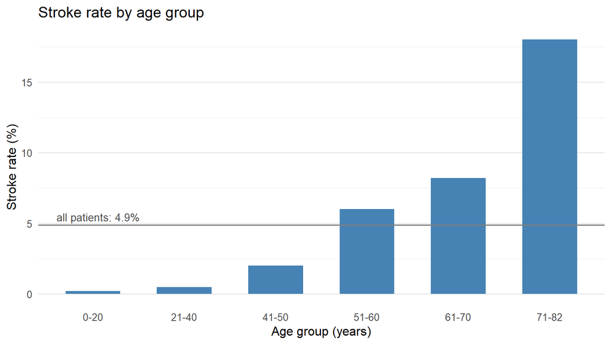

```r
age_plot = ggplot(age_rates, aes(x = group, y = stroke_rate)) +
  geom_col(fill = bar_color, width = 0.6) +
  geom_hline(yintercept = overall_rate, color = "gray50") +
  annotate("text", x = 0.6, y = overall_rate, vjust = -0.5, hjust = 0, size = 3.5, color = "gray30",
           label = sprintf("all patients: %.1f%%", overall_rate)) +
  labs(title = "Stroke rate by age group", x = "Age group (years)", y = "Stroke rate (%)") +
  theme(panel.grid.major.x = element_blank())

age_plot
```

```r
ggsave("figures/stroke_rate_by_age.png", age_plot, width = 8, height = 4.5, dpi = 150, bg = "white")
```

The stroke rate is close to zero under 40 and climbs to 18% in the oldest group.

## Stroke rate by risk factor

```r
glucose_group = cut(stroke_data$avg_glucose_level, breaks = c(0, 100, 140, 200, Inf), right = FALSE,
                    labels = c("< 100", "100-139", "140-199", ">= 200"))
yes_no = function(x) factor(x, levels = 0:1, labels = c("No", "Yes"))

risk_rates = rbind(
  cbind(risk_factor = "Hypertension", stroke_rate_by(yes_no(stroke_data$hypertension), stroke_data$stroke)),
  cbind(risk_factor = "Heart disease", stroke_rate_by(yes_no(stroke_data$heart_disease), stroke_data$stroke)),
  cbind(risk_factor = "Glucose (mg/dL)", stroke_rate_by(glucose_group, stroke_data$stroke)),
  cbind(risk_factor = "Smoking status",
        stroke_rate_by(factor(stroke_data$smoking_status,
                              levels = c("Unknown", "smokes", "formerly smoked", "never smoked")),
                       stroke_data$stroke)),
  cbind(risk_factor = "BMI",
        stroke_rate_by(factor(ifelse(is.na(stroke_data$bmi), "missing", "recorded"),
                              levels = c("recorded", "missing")),
                       stroke_data$stroke))
)
# keep the panels in the order above
risk_rates$risk_factor = factor(risk_rates$risk_factor, levels = unique(risk_rates$risk_factor))
risk_rates
```

```
##        risk_factor           group    n stroke_rate
## 1     Hypertension              No 4611         4.0
## 2     Hypertension             Yes  498        13.3
## 3    Heart disease              No 4833         4.2
## 4    Heart disease             Yes  276        17.0
## 5  Glucose (mg/dL)           < 100 3131         3.6
## 6  Glucose (mg/dL)         100-139 1158         3.8
## 7  Glucose (mg/dL)         140-199  386         9.6
## 8  Glucose (mg/dL)          >= 200  434        12.9
## 9   Smoking status         Unknown 1544         3.0
## 10  Smoking status          smokes  789         5.3
## 11  Smoking status formerly smoked  884         7.9
## 12  Smoking status    never smoked 1892         4.8
## 13             BMI        recorded 4908         4.3
## 14             BMI         missing  201        19.9
```

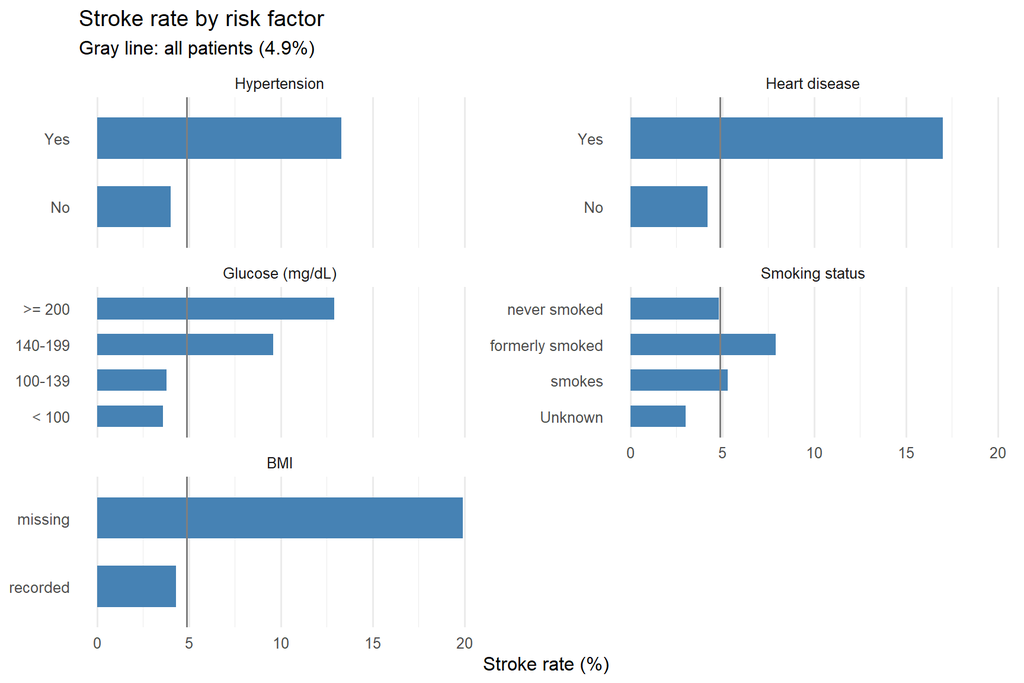

```r
risk_plot = ggplot(risk_rates, aes(x = stroke_rate, y = group)) +
  geom_col(fill = bar_color, width = 0.6) +
  geom_vline(xintercept = overall_rate, color = "gray50") +
  facet_wrap(~ risk_factor, ncol = 2, scales = "free_y") +
  labs(title = "Stroke rate by risk factor",
       subtitle = sprintf("Gray line: all patients (%.1f%%)", overall_rate),
       x = "Stroke rate (%)", y = NULL) +
  theme(panel.grid.major.y = element_blank())

risk_plot
```

```r
ggsave("figures/stroke_rate_by_risk_factor.png", risk_plot, width = 9, height = 6, dpi = 150, bg = "white")
```

Hypertension, heart disease and high glucose all come with clearly higher stroke rates. Two things surprised me: former smokers have a higher rate than current smokers, and patients with a missing BMI have a stroke rate of about 20%. Both are probably partly about age (former smokers and patients with incomplete records tend to be older). The missing BMI pattern is strong enough that I come back to it in the modeling part.

## Correlations

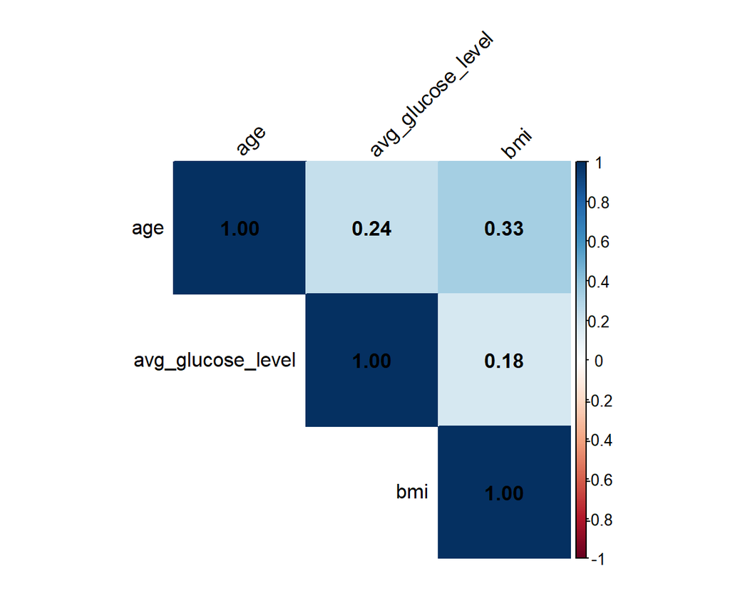

```r
library(corrplot)

cor_matrix = cor(stroke_numeric, use = "complete.obs")
corrplot(cor_matrix, method = "color", type = "upper", addCoef.col = "black",
         tl.col = "black", tl.srt = 45)
```

The numeric variables are only weakly correlated (the strongest pair is age and BMI at 0.33), so collinearity isn’t a concern for the models.

# 3. Logistic Regression

```r
library(caret)
set.seed(123)

stroke_log = stroke_data
for (col in c("gender", "ever_married", "work_type", "Residence_type", "smoking_status")) {
  stroke_log[[col]] = as.factor(stroke_log[[col]])
}
stroke_log$stroke = factor(stroke_log$stroke, levels = c(0, 1), labels = c("No", "Yes"))
# recorded before imputation, used as a feature later
stroke_log$bmi_missing = as.integer(is.na(stroke_log$bmi))
```

## Train-test split

I use a stratified 70/30 split, so both parts keep the same share of stroke patients. Missing BMI values are filled with the median BMI of the training set.

```r
train_index = createDataPartition(stroke_log$stroke, p = 0.7, list = FALSE)
train_data = stroke_log[train_index, ]
test_data = stroke_log[-train_index, ]

bmi_median = median(train_data$bmi, na.rm = TRUE)
train_data$bmi[is.na(train_data$bmi)] = bmi_median
test_data$bmi[is.na(test_data$bmi)] = bmi_median

table(train_data$stroke)
```

```
##
##   No  Yes
## 3402  175
```

```r
table(test_data$stroke)
```

```
##
##   No  Yes
## 1458   74
```

```r
test_strokes = sum(test_data$stroke == "Yes")
```

## Base model

```r
logit_formula = stroke ~ age + hypertension + heart_disease +
  avg_glucose_level + bmi + gender + smoking_status

logit_model = glm(logit_formula, data = train_data, family = binomial)
summary(logit_model)
```

```
##
## Call:
## glm(formula = logit_formula, family = binomial, data = train_data)
##
## Coefficients:
##                             Estimate Std. Error z value Pr(>|z|)
## (Intercept)                -7.251304   0.640431 -11.323   <2e-16 ***
## age                         0.070238   0.006250  11.237   <2e-16 ***
## hypertension                0.300779   0.198641   1.514   0.1300
## heart_disease               0.272721   0.226349   1.205   0.2283
## avg_glucose_level           0.003306   0.001420   2.329   0.0199 *
## bmi                        -0.002556   0.013436  -0.190   0.8491
## genderMale                 -0.006840   0.169139  -0.040   0.9677
## smoking_statusnever smoked -0.285560   0.209659  -1.362   0.1732
## smoking_statussmokes        0.066392   0.255098   0.260   0.7947
## smoking_statusUnknown      -0.076752   0.241259  -0.318   0.7504
## ---
## Signif. codes:  0 '***' 0.001 '**' 0.01 '*' 0.05 '.' 0.1 ' ' 1
##
## (Dispersion parameter for binomial family taken to be 1)
##
##     Null deviance: 1397.4  on 3576  degrees of freedom
## Residual deviance: 1116.6  on 3567  degrees of freedom
## AIC: 1136.6
##
## Number of Fisher Scoring iterations: 7
```

```r
odds_ratios = exp(coef(logit_model))
round(cbind(odds_ratio = odds_ratios, exp(confint(logit_model))), 3)
```

```
##                            odds_ratio 2.5 % 97.5 %
## (Intercept)                     0.001 0.000  0.002
## age                             1.073 1.060  1.086
## hypertension                    1.351 0.908  1.980
## heart_disease                   1.314 0.833  2.026
## avg_glucose_level               1.003 1.000  1.006
## bmi                             0.997 0.971  1.024
## genderMale                      0.993 0.711  1.381
## smoking_statusnever smoked      0.752 0.499  1.137
## smoking_statussmokes            1.069 0.642  1.752
## smoking_statusUnknown           0.926 0.574  1.482
```

```r
p_values = coef(summary(logit_model))[, 4]
```

Age is the strongest predictor: every extra year multiplies the odds of stroke by 1.073, which is about 7.3% higher odds per year. Glucose level is also significant (p = 0.02). Hypertension (p = 0.13) and heart disease (p = 0.23) are not, even though their raw stroke rates were much higher. They overlap a lot with age, and once age is in the model there isn’t much left for them to explain.

## The 0.5 threshold problem

The model gives a probability for each patient, and the usual rule is to predict “stroke” above 0.5.

```r
logit_pred_prob = predict(logit_model, newdata = test_data, type = "response")
logit_pred_class = factor(ifelse(logit_pred_prob > 0.5, "Yes", "No"), levels = c("No", "Yes"))

cm_logit = confusionMatrix(logit_pred_class, test_data$stroke, positive = "Yes")
cm_logit
```

```
## Confusion Matrix and Statistics
##
##           Reference
## Prediction   No  Yes
##        No  1458   74
##        Yes    0    0
##
##                Accuracy : 0.9517
##                  95% CI : (0.9397, 0.9619)
##     No Information Rate : 0.9517
##     P-Value [Acc > NIR] : 0.5309
##
##                   Kappa : 0
##
##  Mcnemar's Test P-Value : <2e-16
##
##             Sensitivity : 0.0000
##             Specificity : 1.0000
##          Pos Pred Value :    NaN
##          Neg Pred Value : 0.9517
##              Prevalence : 0.0483
##          Detection Rate : 0.0000
##    Detection Prevalence : 0.0000
##       Balanced Accuracy : 0.5000
##
##        'Positive' Class : Yes
##
```

With 0.5 the model predicts “no stroke” for everyone, because the highest predicted probability in the test set is only 0.46. Accuracy is still 95.2%, simply because most patients didn’t have a stroke.

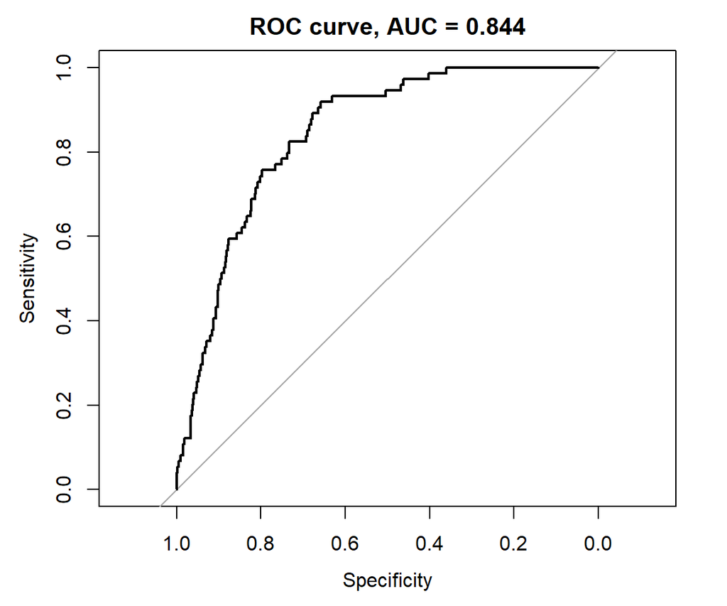

```r
library(pROC)

roc_obj = roc(test_data$stroke, logit_pred_prob, quiet = TRUE)
auc_value = auc(roc_obj)
plot(roc_obj, main = paste("ROC curve, AUC =", round(auc_value, 3)))
```

The AUC is 0.84, so the model ranks patients reasonably well. The ranking is fine; the 0.5 cutoff is what doesn’t work.

## Choosing a better threshold

To pick a cutoff without looking at the test set, I run 5-fold cross-validation on the training data. Every training patient gets a predicted probability from a model that wasn’t trained on them, and I choose the threshold with the best F1 score on those out-of-fold predictions.

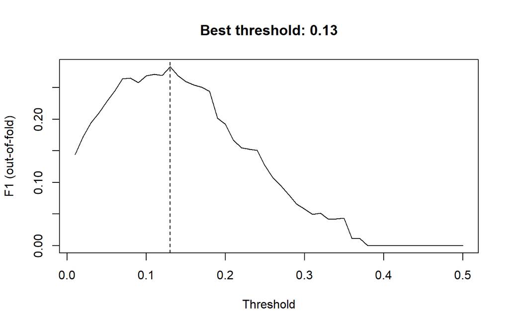

```r
f1_at_threshold = function(prob, actual, threshold) {
  pred_yes = prob >= threshold
  is_yes = actual == "Yes"
  tp = sum(pred_yes & is_yes)
  fp = sum(pred_yes & !is_yes)
  fn = sum(!pred_yes & is_yes)
  if (tp == 0) return(0)
  2 * tp / (2 * tp + fp + fn)
}

thresholds = seq(0.01, 0.50, by = 0.01)
best_f1_threshold = function(prob, actual) {
  f1_scores = sapply(thresholds, function(t) f1_at_threshold(prob, actual, t))
  thresholds[which.max(f1_scores)]
}

set.seed(123)
folds = createFolds(train_data$stroke, k = 5)
oof_glm = function(formula) {
  prob = numeric(nrow(train_data))
  for (fold in folds) {
    fold_model = glm(formula, data = train_data[-fold, ], family = binomial)
    prob[fold] = predict(fold_model, newdata = train_data[fold, ], type = "response")
  }
  prob
}

oof_prob = oof_glm(logit_formula)
best_threshold = best_f1_threshold(oof_prob, train_data$stroke)

f1_scores = sapply(thresholds, function(t) f1_at_threshold(oof_prob, train_data$stroke, t))
plot(thresholds, f1_scores, type = "l", xlab = "Threshold", ylab = "F1 (out-of-fold)",
     main = paste("Best threshold:", best_threshold))
abline(v = best_threshold, lty = 2)
```

```r
logit_pred_tuned = factor(ifelse(logit_pred_prob >= best_threshold, "Yes", "No"), levels = c("No", "Yes"))

cm_tuned = confusionMatrix(logit_pred_tuned, test_data$stroke, positive = "Yes", mode = "everything")
cm_tuned
```

```
## Confusion Matrix and Statistics
##
##           Reference
## Prediction   No  Yes
##        No  1299   36
##        Yes  159   38
##
##                Accuracy : 0.8727
##                  95% CI : (0.855, 0.889)
##     No Information Rate : 0.9517
##     P-Value [Acc > NIR] : 1
##
##                   Kappa : 0.2261
##
##  Mcnemar's Test P-Value : <2e-16
##
##             Sensitivity : 0.5135
##             Specificity : 0.8909
##          Pos Pred Value : 0.1929
##          Neg Pred Value : 0.9730
##               Precision : 0.1929
##                  Recall : 0.5135
##                      F1 : 0.2804
##              Prevalence : 0.0483
##          Detection Rate : 0.0248
##    Detection Prevalence : 0.1286
##       Balanced Accuracy : 0.7022
##
##        'Positive' Class : Yes
##
```

With a threshold of 0.13 the model finds 38 of the 74 stroke patients in the test set. The price is a lot of false alarms: the precision is 19.3%, so only about one in five flagged patients actually had a stroke.

When the positive class is this rare, the precision-recall curve is more informative than the ROC curve. A random model would get a PR-AUC equal to the stroke rate (about 0.05).

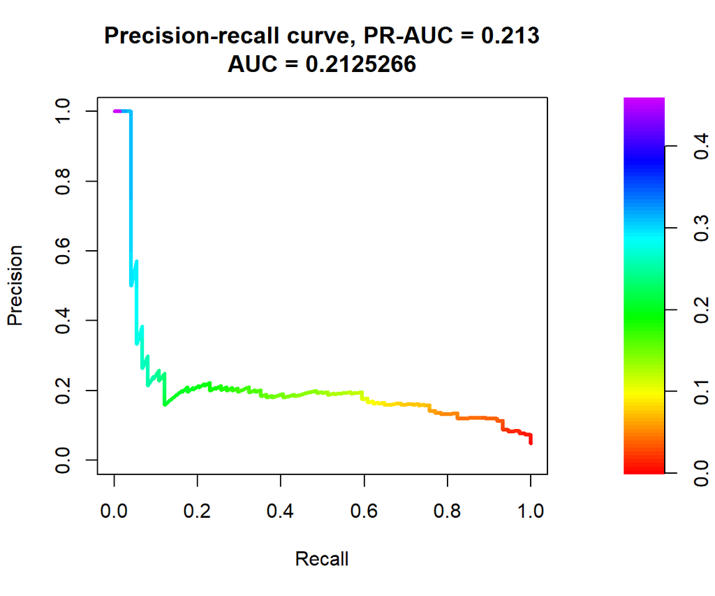

```r
library(PRROC)

pr = pr.curve(scores.class0 = logit_pred_prob[test_data$stroke == "Yes"],
              scores.class1 = logit_pred_prob[test_data$stroke == "No"],
              curve = TRUE)
plot(pr, main = paste("Precision-recall curve, PR-AUC =", round(pr$auc.integral, 3)))
```

## Feature engineering

The exploratory analysis suggested two things to try. Patients with a missing BMI had a much higher stroke rate, so the fact that BMI is missing might carry information that the median imputation throws away. And the age effect might not be linear on the log-odds scale, so I also try adding a squared age term. I add each idea to the base model separately and compare them with likelihood-ratio tests.

```r
flag_formula = update(logit_formula, . ~ . + bmi_missing)
quadratic_formula = update(logit_formula, . ~ . + I(age^2))

logit_flag = glm(flag_formula, data = train_data, family = binomial)
logit_quadratic = glm(quadratic_formula, data = train_data, family = binomial)

data.frame(model = c("base", "base + BMI missing flag", "base + squared age"),
           AIC = round(c(AIC(logit_model), AIC(logit_flag), AIC(logit_quadratic)), 1))
```

```
##                     model    AIC
## 1                    base 1136.6
## 2 base + BMI missing flag 1107.4
## 3      base + squared age 1138.3
```

```r
flag_test = anova(logit_model, logit_flag, test = "Chisq")
quadratic_test = anova(logit_model, logit_quadratic, test = "Chisq")
flag_test
```

```
## Analysis of Deviance Table
##
## Model 1: stroke ~ age + hypertension + heart_disease + avg_glucose_level +
##     bmi + gender + smoking_status
## Model 2: stroke ~ age + hypertension + heart_disease + avg_glucose_level +
##     bmi + gender + smoking_status + bmi_missing
##   Resid. Df Resid. Dev Df Deviance  Pr(>Chi)
## 1      3567     1116.6
## 2      3566     1085.4  1   31.209 2.317e-08 ***
## ---
## Signif. codes:  0 '***' 0.001 '**' 0.01 '*' 0.05 '.' 0.1 ' ' 1
```

```r
quadratic_test
```

```
## Analysis of Deviance Table
##
## Model 1: stroke ~ age + hypertension + heart_disease + avg_glucose_level +
##     bmi + gender + smoking_status
## Model 2: stroke ~ age + hypertension + heart_disease + avg_glucose_level +
##     bmi + gender + smoking_status + I(age^2)
##   Resid. Df Resid. Dev Df Deviance Pr(>Chi)
## 1      3567     1116.6
## 2      3566     1116.3  1  0.29429   0.5875
```

The missing-BMI flag clearly improves the model: AIC drops by 29.2 and the likelihood-ratio test gives p = 2.3e-08. Even after adjusting for age and the other variables, patients without a recorded BMI have 4.6 times higher odds of stroke. My guess is that a missing measurement often means a patient who was too ill or too urgent to be measured, but the data can’t confirm that.

```r
flag_oof_prob = oof_glm(flag_formula)
flag_best_threshold = best_f1_threshold(flag_oof_prob, train_data$stroke)

flag_test_prob = predict(logit_flag, newdata = test_data, type = "response")
flag_pred_tuned = factor(ifelse(flag_test_prob >= flag_best_threshold, "Yes", "No"), levels = c("No", "Yes"))

cm_flag = confusionMatrix(flag_pred_tuned, test_data$stroke, positive = "Yes", mode = "everything")
cm_flag
```

```
## Confusion Matrix and Statistics
##
##           Reference
## Prediction   No  Yes
##        No  1283   32
##        Yes  175   42
##
##                Accuracy : 0.8649
##                  95% CI : (0.8467, 0.8816)
##     No Information Rate : 0.9517
##     P-Value [Acc > NIR] : 1
##
##                   Kappa : 0.2334
##
##  Mcnemar's Test P-Value : <2e-16
##
##             Sensitivity : 0.56757
##             Specificity : 0.87997
##          Pos Pred Value : 0.19355
##          Neg Pred Value : 0.97567
##               Precision : 0.19355
##                  Recall : 0.56757
##                      F1 : 0.28866
##              Prevalence : 0.04830
##          Detection Rate : 0.02742
##    Detection Prevalence : 0.14164
##       Balanced Accuracy : 0.72377
##
##        'Positive' Class : Yes
##
```

On this test set the model with the flag finds 42 of the 74 stroke patients at a threshold of 0.12. One split with 74 stroke patients is noisy, so whether the flag really helps is checked with repeated cross-validation in section 7.

# 4. Linear Discriminant Analysis

LDA is a classic alternative to logistic regression. It assumes that within each class the predictors are normally distributed with the same covariance, and uses Bayes’ rule to turn that into a probability of stroke. It gets the same features, split, folds and threshold search as the logistic regression, so the two can be compared directly.

R turns the categorical variables into 0/1 dummy columns automatically: one column per category, minus a reference category. Coding them as 1, 2, 3, 4 instead would pretend the categories have an order. The made-up example below shows the idea for smoking status, where “formerly smoked” is the reference.

```r
library(MASS)

dummy_example = data.frame(smoking_status = factor(c("never smoked", "smokes", "Unknown", "formerly smoked")))
model.matrix(~ smoking_status, data = dummy_example)
```

```
##   (Intercept) smoking_statusnever smoked smoking_statussmokes
## 1           1                          1                    0
## 2           1                          0                    1
## 3           1                          0                    0
## 4           1                          0                    0
##   smoking_statusUnknown
## 1                     0
## 2                     0
## 3                     1
## 4                     0
## attr(,"assign")
## [1] 0 1 1 1
## attr(,"contrasts")
## attr(,"contrasts")$smoking_status
## [1] "contr.treatment"
```

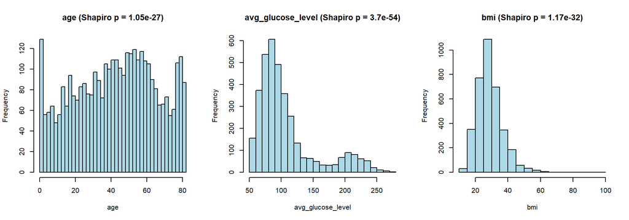

```r
par(mfrow = c(1, 3))
for (var in numeric_vars) {
  # shapiro.test accepts at most 5000 values
  shapiro_p = shapiro.test(sample(train_data[[var]], min(5000, nrow(train_data))))$p.value
  hist(train_data[[var]], breaks = 30, col = "lightblue", xlab = var,
       main = sprintf("%s (Shapiro p = %.3g)", var, shapiro_p))
}
```

None of the numeric variables look normal, and the Shapiro-Wilk test agrees. The binary and dummy columns can’t be normal either, so LDA’s assumptions don’t really hold here. I still include it as a comparison.

```r
lda_model = lda(flag_formula, data = train_data)
lda_model
```

```
## Call:
## lda(flag_formula, data = train_data)
##
## Prior probabilities of groups:
##         No        Yes
## 0.95107632 0.04892368
##
## Group means:
##          age hypertension heart_disease avg_glucose_level      bmi genderMale
## No  41.77263   0.09112287    0.04879483          105.6873 28.81961  0.4044680
## Yes 67.83611   0.25142857    0.18857143          131.3814 29.89714  0.4285714
##     smoking_statusnever smoked smoking_statussmokes smoking_statusUnknown
## No                   0.3715461            0.1502058             0.3098178
## Yes                  0.3428571            0.1657143             0.2000000
##     bmi_missing
## No    0.0335097
## Yes   0.1714286
##
## Coefficients of linear discriminants:
##                                     LD1
## age                         0.035642362
## hypertension                0.451734872
## heart_disease               0.760511970
## avg_glucose_level           0.003559684
## bmi                        -0.021752387
## genderMale                 -0.020867658
## smoking_statusnever smoked -0.198327957
## smoking_statussmokes       -0.205724860
## smoking_statusUnknown       0.128997598
## bmi_missing                 2.175339590
```

```r
lda_oof_prob = numeric(nrow(train_data))
for (fold in folds) {
  fold_model = lda(flag_formula, data = train_data[-fold, ])
  lda_oof_prob[fold] = predict(fold_model, newdata = train_data[fold, ])$posterior[, "Yes"]
}
lda_best_threshold = best_f1_threshold(lda_oof_prob, train_data$stroke)

lda_test_prob = predict(lda_model, newdata = test_data)$posterior[, "Yes"]
lda_pred_tuned = factor(ifelse(lda_test_prob >= lda_best_threshold, "Yes", "No"), levels = c("No", "Yes"))

cm_lda = confusionMatrix(lda_pred_tuned, test_data$stroke, positive = "Yes", mode = "everything")
cm_lda
```

```
## Confusion Matrix and Statistics
##
##           Reference
## Prediction   No  Yes
##        No  1292   34
##        Yes  166   40
##
##                Accuracy : 0.8695
##                  95% CI : (0.8515, 0.8859)
##     No Information Rate : 0.9517
##     P-Value [Acc > NIR] : 1
##
##                   Kappa : 0.2311
##
##  Mcnemar's Test P-Value : <2e-16
##
##             Sensitivity : 0.54054
##             Specificity : 0.88615
##          Pos Pred Value : 0.19417
##          Neg Pred Value : 0.97436
##               Precision : 0.19417
##                  Recall : 0.54054
##                      F1 : 0.28571
##              Prevalence : 0.04830
##          Detection Rate : 0.02611
##    Detection Prevalence : 0.13446
##       Balanced Accuracy : 0.71334
##
##        'Positive' Class : Yes
##
```

LDA’s best threshold is 0.09, and it finds 40 of the 74 stroke patients.

# 5. Random Forest

A random forest builds many decision trees on bootstrap samples of the data and averages their predictions. Unlike the other two models, it can pick up non-linear effects and interactions without me specifying them. I use the `ranger` package with 500 trees and the default settings.

```r
library(ranger)

set.seed(123)
rf_model = ranger(flag_formula, data = train_data, num.trees = 500,
                  probability = TRUE, importance = "permutation")
rf_model
```

```
## Ranger result
##
## Call:
##  ranger(flag_formula, data = train_data, num.trees = 500, probability = TRUE,      importance = "permutation")
##
## Type:                             Probability estimation
## Number of trees:                  500
## Sample size:                      3577
## Number of independent variables:  8
## Mtry:                             2
## Target node size:                 10
## Variable importance mode:         permutation
## Splitrule:                        gini
## OOB prediction error (Brier s.):  0.04278993
```

Each tree skips about a third of the training patients, so the forest can predict every training patient using only the trees that didn’t see them. I use these out-of-bag predictions to choose the threshold, the same way I used cross-validation for the other models.

```r
rf_oob_prob = rf_model$predictions[, "Yes"]
rf_best_threshold = best_f1_threshold(rf_oob_prob, train_data$stroke)

rf_test_prob = predict(rf_model, data = test_data)$predictions[, "Yes"]
rf_pred_tuned = factor(ifelse(rf_test_prob >= rf_best_threshold, "Yes", "No"), levels = c("No", "Yes"))

cm_rf = confusionMatrix(rf_pred_tuned, test_data$stroke, positive = "Yes", mode = "everything")
cm_rf
```

```
## Confusion Matrix and Statistics
##
##           Reference
## Prediction   No  Yes
##        No  1338   45
##        Yes  120   29
##
##                Accuracy : 0.8923
##                  95% CI : (0.8757, 0.9074)
##     No Information Rate : 0.9517
##     P-Value [Acc > NIR] : 1
##
##                   Kappa : 0.209
##
##  Mcnemar's Test P-Value : 8.367e-09
##
##             Sensitivity : 0.39189
##             Specificity : 0.91770
##          Pos Pred Value : 0.19463
##          Neg Pred Value : 0.96746
##               Precision : 0.19463
##                  Recall : 0.39189
##                      F1 : 0.26009
##              Prevalence : 0.04830
##          Detection Rate : 0.01893
##    Detection Prevalence : 0.09726
##       Balanced Accuracy : 0.65479
##
##        'Positive' Class : Yes
##
```

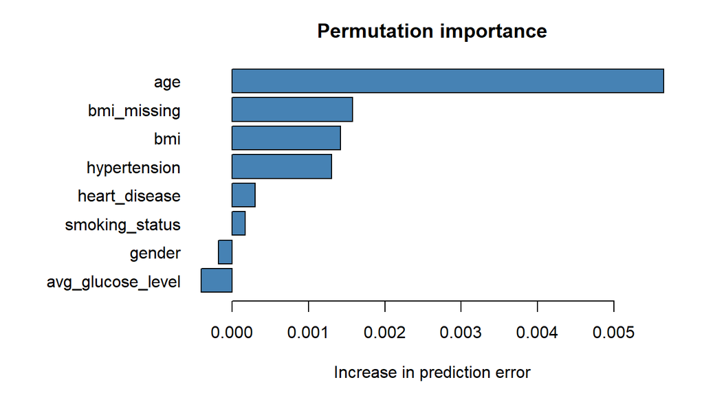

```r
par(mar = c(5, 10, 3, 2))
barplot(sort(importance(rf_model)), horiz = TRUE, las = 1, col = "steelblue",
        main = "Permutation importance", xlab = "Increase in prediction error")
```

Age is by far the most important variable for the forest. Permutation importance on a probability forest is measured with the Brier score, and with so few stroke cases the smaller values are close to noise, so I only read the top of this chart. Random forests also tend to favor continuous variables that have many possible split points.

## All models on the test set

```r
model_metrics = function(prob, pred, actual) {
  cm = confusionMatrix(pred, actual, positive = "Yes", mode = "everything")
  c(AUC = as.numeric(auc(roc(actual, prob, quiet = TRUE))),
    PR_AUC = pr.curve(scores.class0 = prob[actual == "Yes"],
                      scores.class1 = prob[actual == "No"])$auc.integral,
    Brier = mean((prob - (actual == "Yes"))^2),
    Recall = unname(cm$byClass["Recall"]),
    Precision = unname(cm$byClass["Precision"]),
    F1 = unname(cm$byClass["F1"]))
}

comparison = rbind(
  "Logistic regression (base)" = c(Threshold = best_threshold,
                                   model_metrics(logit_pred_prob, logit_pred_tuned, test_data$stroke)),
  "Logistic regression + BMI flag" = c(Threshold = flag_best_threshold,
                                       model_metrics(flag_test_prob, flag_pred_tuned, test_data$stroke)),
  "LDA" = c(Threshold = lda_best_threshold,
            model_metrics(lda_test_prob, lda_pred_tuned, test_data$stroke)),
  "Random forest" = c(Threshold = rf_best_threshold,
                      model_metrics(rf_test_prob, rf_pred_tuned, test_data$stroke))
)
round(comparison, 3)
```

```
##                                Threshold   AUC PR_AUC Brier Recall Precision
## Logistic regression (base)          0.13 0.844  0.213 0.042  0.514     0.193
## Logistic regression + BMI flag      0.12 0.848  0.193 0.042  0.568     0.194
## LDA                                 0.09 0.849  0.183 0.049  0.541     0.194
## Random forest                       0.15 0.828  0.220 0.042  0.392     0.195
##                                   F1
## Logistic regression (base)     0.280
## Logistic regression + BMI flag 0.289
## LDA                            0.286
## Random forest                  0.260
```

On a single test set the models are close, and the differences between them are within the range that a few patients can change. Section 7 compares them more reliably.

# 6. Calibration and Threshold Choice

## Calibration

A model can rank patients well and still give probabilities that are too high or too low. If the output is going to be read as a risk (“this patient has a 15% chance”), that matters. To check it, I sort the test patients by predicted risk, split them into ten equal groups, and compare the average predicted risk with the actual stroke rate in each group.

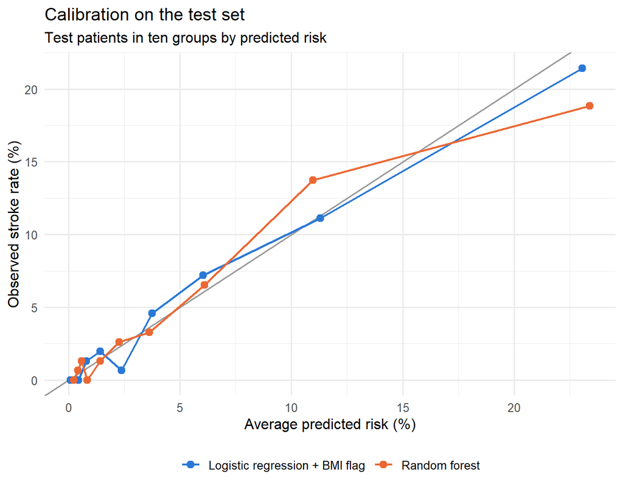

```r
calibration_bins = function(prob, actual, model_name, bins = 10) {
  bin = cut(prob, breaks = unique(quantile(prob, probs = seq(0, 1, length.out = bins + 1))),
            include.lowest = TRUE)
  data.frame(model = model_name,
             predicted = as.vector(tapply(prob, bin, mean)) * 100,
             observed = as.vector(tapply(actual == "Yes", bin, mean)) * 100)
}

calibration = rbind(
  calibration_bins(flag_test_prob, test_data$stroke, "Logistic regression + BMI flag"),
  calibration_bins(rf_test_prob, test_data$stroke, "Random forest")
)

calibration_plot = ggplot(calibration, aes(x = predicted, y = observed, color = model)) +
  geom_abline(slope = 1, intercept = 0, color = "gray60") +
  geom_line(linewidth = 0.8) +
  geom_point(size = 2.5) +
  scale_color_manual(values = c("#2a78d6", "#eb6834")) +
  labs(title = "Calibration on the test set",
       subtitle = "Test patients in ten groups by predicted risk",
       x = "Average predicted risk (%)", y = "Observed stroke rate (%)", color = NULL) +
  theme(legend.position = "bottom")

calibration_plot
```

```r
ggsave("figures/calibration.png", calibration_plot, width = 7, height = 5.5, dpi = 150, bg = "white")
```

Points on the gray line mean the predicted risk matches reality. The Brier score summarizes this in one number (the mean squared difference between the predicted probability and the actual 0/1 outcome, lower is better): 0.0421 for the logistic regression and 0.0423 for the random forest. For reference, always predicting the overall stroke rate would give about 0.0464. The highest risk groups contain only a handful of stroke patients, so the right end of the chart is noisy.

## A threshold for screening

The F1 threshold treats a missed stroke and a false alarm roughly the same. If this were used for screening, missing a stroke patient would be much worse than sending someone for an extra check. As an alternative I pick the highest threshold that still reaches 80% recall on the out-of-fold training predictions, and see what it costs on the test set.

```r
threshold_for_recall = function(prob, actual, target_recall) {
  recall = sapply(thresholds, function(t) mean(prob[actual == "Yes"] >= t))
  max(thresholds[recall >= target_recall])
}

screen_threshold = threshold_for_recall(flag_oof_prob, train_data$stroke, 0.8)

threshold_summary = function(threshold) {
  pred_yes = flag_test_prob >= threshold
  is_yes = test_data$stroke == "Yes"
  c(threshold = threshold,
    recall = mean(pred_yes[is_yes]),
    precision = mean(is_yes[pred_yes]),
    share_flagged = mean(pred_yes))
}

threshold_options = rbind("max F1" = threshold_summary(flag_best_threshold),
                          "80% recall" = threshold_summary(screen_threshold))
round(threshold_options, 3)
```

```
##            threshold recall precision share_flagged
## max F1          0.12  0.568     0.194         0.142
## 80% recall      0.04  0.838     0.121         0.336
```

With the screening threshold of 0.04 the model catches 83.8% of the stroke patients in the test set, but it flags 33.6% of all patients and the precision drops to 12.1%. Which one is better depends on how expensive a follow-up check is compared with a missed stroke, and that has to be decided by whoever would use the model.

# 7. Repeated Cross-Validation

One test set with 74 stroke patients is small: a few patients more or less can move recall by several percentage points. To get more stable numbers, I repeat the whole process with 5-fold cross-validation, 10 times, which gives 50 results per model. Inside each fold, the BMI median and the F1 threshold are computed from that fold’s training part only (the threshold with an inner 5-fold cross-validation), so the held-out part is never used for any decision.

```r
impute_bmi = function(train, test) {
  bmi_median = median(train$bmi, na.rm = TRUE)
  train$bmi[is.na(train$bmi)] = bmi_median
  test$bmi[is.na(test$bmi)] = bmi_median
  list(train = train, test = test)
}

# each fit_predict function trains on `train` and returns P(stroke) for `test`
fit_predict_glm = function(formula) {
  function(train, test) {
    model = glm(formula, data = train, family = binomial)
    predict(model, newdata = test, type = "response")
  }
}

fit_predict_lda = function(train, test) {
  model = lda(flag_formula, data = train)
  predict(model, newdata = test)$posterior[, "Yes"]
}

fit_predict_rf = function(train, test) {
  model = ranger(flag_formula, data = train, num.trees = 500, probability = TRUE)
  predict(model, data = test)$predictions[, "Yes"]
}

choose_threshold = function(train, fit_predict) {
  inner_folds = createFolds(train$stroke, k = 5)
  prob = numeric(nrow(train))
  for (fold in inner_folds) {
    prob[fold] = fit_predict(train[-fold, ], train[fold, ])
  }
  best_f1_threshold(prob, train$stroke)
}
```

```r
set.seed(2024)
n_repeats = 10
k_outer = 5
models = list("Logistic regression (base)" = fit_predict_glm(logit_formula),
              "Logistic regression + BMI flag" = fit_predict_glm(flag_formula),
              "LDA" = fit_predict_lda,
              "Random forest" = fit_predict_rf)

cv_results = list()
for (r in 1:n_repeats) {
  outer_folds = createFolds(stroke_log$stroke, k = k_outer)
  for (f in seq_along(outer_folds)) {
    fold_data = impute_bmi(stroke_log[-outer_folds[[f]], ], stroke_log[outer_folds[[f]], ])
    for (model_name in names(models)) {
      fit_predict = models[[model_name]]
      threshold = choose_threshold(fold_data$train, fit_predict)
      prob = fit_predict(fold_data$train, fold_data$test)
      pred = factor(ifelse(prob >= threshold, "Yes", "No"), levels = c("No", "Yes"))
      cv_results[[length(cv_results) + 1]] = data.frame(
        repeat_id = r, fold = f, model = model_name,
        t(model_metrics(prob, pred, fold_data$test$stroke))
      )
    }
  }
}
cv_results = do.call(rbind, cv_results)
```

```r
metric_cols = c("AUC", "PR_AUC", "Brier", "Recall", "Precision", "F1")
mean_sd = function(x) sprintf("%.3f ± %.3f", mean(x), sd(x))

cv_summary = sapply(split(cv_results[, metric_cols], cv_results$model),
                    function(df) sapply(df, mean_sd))
noquote(t(cv_summary))
```

```
##                                AUC           PR_AUC        Brier
## LDA                            0.841 ± 0.024 0.199 ± 0.034 0.047 ± 0.003
## Logistic regression (base)     0.841 ± 0.025 0.192 ± 0.038 0.043 ± 0.001
## Logistic regression + BMI flag 0.850 ± 0.025 0.215 ± 0.041 0.042 ± 0.001
## Random forest                  0.839 ± 0.024 0.217 ± 0.038 0.042 ± 0.001
##                                Recall        Precision     F1
## LDA                            0.450 ± 0.083 0.204 ± 0.031 0.278 ± 0.035
## Logistic regression (base)     0.535 ± 0.105 0.181 ± 0.025 0.269 ± 0.036
## Logistic regression + BMI flag 0.483 ± 0.099 0.208 ± 0.035 0.287 ± 0.040
## Random forest                  0.476 ± 0.111 0.197 ± 0.035 0.274 ± 0.043
```

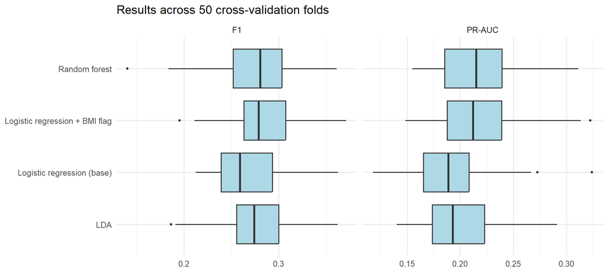

```r
cv_long = rbind(
  data.frame(model = cv_results$model, metric = "PR-AUC", value = cv_results$PR_AUC),
  data.frame(model = cv_results$model, metric = "F1", value = cv_results$F1)
)

ggplot(cv_long, aes(x = value, y = model)) +
  geom_boxplot(fill = "lightblue", outlier.size = 1) +
  facet_wrap(~ metric, scales = "free_x") +
  labs(title = "Results across 50 cross-validation folds", x = NULL, y = NULL)
```

## Comparing the models fold by fold

All models were evaluated on the same folds, so I compare them fold by fold using the difference in each metric. A regular paired t-test would be too optimistic here: the training sets of different folds share most of their patients, so the 50 results are not independent. I use the corrected resampled t-test from Nadeau and Bengio (2003), which inflates the variance to account for that overlap.

```r
corrected_t_test = function(d, test_train_ratio) {
  J = length(d)
  se = sqrt((1 / J + test_train_ratio) * var(d))
  t_stat = mean(d) / se
  list(t = t_stat, p_value = 2 * pt(-abs(t_stat), df = J - 1))
}

compare_models = function(model_a, model_b, metric) {
  d = cv_results[cv_results$model == model_a, metric] - cv_results[cv_results$model == model_b, metric]
  test = corrected_t_test(d, test_train_ratio = 1 / (k_outer - 1))
  data.frame(comparison = paste(model_a, "vs", model_b), metric = metric,
             mean_difference = round(mean(d), 4), a_better_in = sum(d > 0),
             t = round(test$t, 2), p_value = round(test$p_value, 3))
}

final_model = "Logistic regression + BMI flag"
pairwise = do.call(rbind, lapply(c("Logistic regression (base)", "LDA", "Random forest"), function(other) {
  do.call(rbind, lapply(c("AUC", "PR_AUC", "F1"), function(metric) compare_models(final_model, other, metric)))
}))
pairwise
```

```
##                                                     comparison metric
## 1 Logistic regression + BMI flag vs Logistic regression (base)    AUC
## 2 Logistic regression + BMI flag vs Logistic regression (base) PR_AUC
## 3 Logistic regression + BMI flag vs Logistic regression (base)     F1
## 4                        Logistic regression + BMI flag vs LDA    AUC
## 5                        Logistic regression + BMI flag vs LDA PR_AUC
## 6                        Logistic regression + BMI flag vs LDA     F1
## 7              Logistic regression + BMI flag vs Random forest    AUC
## 8              Logistic regression + BMI flag vs Random forest PR_AUC
## 9              Logistic regression + BMI flag vs Random forest     F1
##   mean_difference a_better_in     t p_value
## 1          0.0099          49  3.40   0.001
## 2          0.0231          38  1.50   0.141
## 3          0.0181          41  1.07   0.289
## 4          0.0094          40  1.86   0.068
## 5          0.0161          43  1.44   0.156
## 6          0.0088          28  0.50   0.623
## 7          0.0111          42  1.96   0.056
## 8         -0.0015          21 -0.10   0.924
## 9          0.0130          34  0.72   0.472
```

`a_better_in` is the number of folds (out of 50) in which the logistic regression with the BMI flag scored higher.

Compared with the base logistic regression, the flag gives a small but consistent AUC gain: it is better in 49 of the 50 folds (p = 0.001). The PR-AUC and F1 gains point the same way but are within the noise. Against LDA and the random forest none of the differences reach p < 0.05, and on PR-AUC the random forest is practically tied with it. So the extra complexity of the random forest doesn’t buy anything on this data.

# 8. Summary

Age is by far the strongest factor: the stroke rate goes from 0.2% in the youngest group to 18% in the oldest, and each extra year multiplies the odds of stroke by 1.073. Glucose level also matters. A missing BMI turned out to be a strong signal as well, with 4.6 times higher odds after adjusting for everything else.

The class imbalance was the main practical problem. With the default 0.5 threshold the base logistic regression is 95.2% accurate and finds 0 of the 74 stroke patients in the test set. Choosing the threshold by cross-validation on the training data (0.13) brings that to 38. For screening, a threshold aimed at 80% recall catches 83.8% of stroke patients but flags 33.6% of everyone.

In 10 × 5 cross-validation, adding the missing-BMI flag raised the mean PR-AUC of the logistic regression from 0.192 to 0.215 (corrected p = 0.141) and the mean AUC from 0.841 to 0.85 (p = 0.001). Its mean F1 was 0.287, compared with 0.278 for LDA and 0.274 for the random forest. LDA and the random forest did not improve on it, so I would use the logistic regression with the BMI flag: it performs at least as well as the other models, it is reasonably calibrated, and its coefficients are easy to explain.

## Limitations

- This is observational data, so everything here is an association. The raw group comparisons in particular are mixed up with age, and I can only guess why a missing BMI is linked to stroke.
- Precision stays around 20.8% with the F1 threshold. A model like this could be a first screening step at best, not something that makes decisions on its own.
- About 30% of the smoking status values are “Unknown”.
- The random forest was not tuned, and everything is based on a single dataset without external validation.

## Next steps

- Tune the random forest (or try gradient boosting) inside the same nested cross-validation.
- Use class weights as an alternative to threshold tuning and compare the two approaches.
- Choose the threshold from actual costs of a missed stroke and a follow-up check, if those can be estimated.
- Validate the final model on data from a different source.